# Reproducable Research Assignment 1

=====================================================================================================

We start with downloading the data into a data frame(df)

```r
df<-read.csv("activity.csv")
head(df)
```

```
##   steps       date interval
## 1    NA 2012-10-01        0
## 2    NA 2012-10-01        5
## 3    NA 2012-10-01       10
## 4    NA 2012-10-01       15
## 5    NA 2012-10-01       20
## 6    NA 2012-10-01       25
```

```r
str(df)
```

```
## 'data.frame':    17568 obs. of  3 variables:
##  $ steps   : int  NA NA NA NA NA NA NA NA NA NA ...
##  $ date    : Factor w/ 61 levels "2012-10-01","2012-10-02",..: 1 1 1 1 1 1 1 1 1 1 ...
##  $ interval: int  0 5 10 15 20 25 30 35 40 45 ...
```

Now that we have familiarized ourselves with the dataset, we will start with the analysis that has been asked of us as part of this assignment

```r
#We download the library files for the analysis
library(ggplot2)
library(gridExtra)
```

### Histogram of the total number of steps taken each day

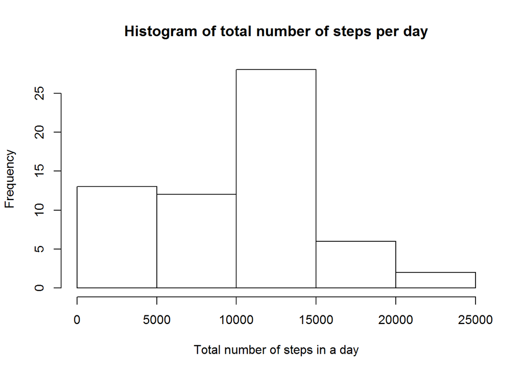

```r
#we start with saving the sum of all steps each day in a dataframe(dftemp)
dftemp<-aggregate(df$steps, by=list(date=df$date), FUN=sum)
#set NA values to zero
dftemp[is.na(dftemp)]<-0
hist(dftemp$x,main="Histogram of total number of steps per day",  xlab="Total number of steps in a day")
```

### Mean and median number of steps taken each day

```r
dfmean<- aggregate(df$steps, by=list(date=df$date), FUN=mean)
colnames(dfmean)<-c("Date","Mean")
summary(dfmean)
```

```
##          Date         Mean
##  2012-10-01: 1   Min.   : 0.1424
##  2012-10-02: 1   1st Qu.:30.6979
##  2012-10-03: 1   Median :37.3785
##  2012-10-04: 1   Mean   :37.3826
##  2012-10-05: 1   3rd Qu.:46.1597
##  2012-10-06: 1   Max.   :73.5903
##  (Other)   :55   NA's   :8
```

```r
dfmedian<- aggregate(df$steps, by=list(date=df$date), FUN=median, na.rm=T)
colnames(dfmedian)<-c("Date","Median")
summary(dfmedian)
```

```
##          Date        Median
##  2012-10-01: 1   Min.   :0
##  2012-10-02: 1   1st Qu.:0
##  2012-10-03: 1   Median :0
##  2012-10-04: 1   Mean   :0
##  2012-10-05: 1   3rd Qu.:0
##  2012-10-06: 1   Max.   :0
##  (Other)   :55   NA's   :8
```

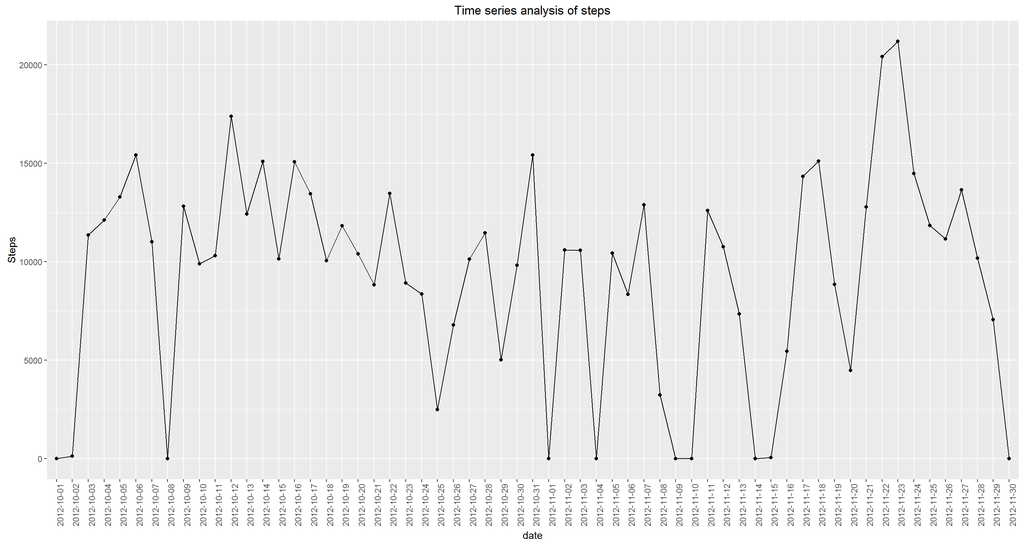

```r
mp<-ggplot(dftemp,aes(x=date,y=x))+ geom_point()+geom_line(aes(group=1))+theme(axis.text.x = element_text(angle = 90, hjust = 1))+ylab("Steps")+ggtitle("Time series analysis of steps")

mp
```

### The 5-minute interval that, on average, contains the maximum number of steps

```r
dfmeanint<- aggregate(df$steps, by=list(interval=df$interval), FUN=mean,na.rm=T)
colnames(dfmeanint)<- c("Interval","Average.steps")
head(dfmeanint)
```

```
##   Interval Average.steps
## 1        0     1.7169811
## 2        5     0.3396226
## 3       10     0.1320755
## 4       15     0.1509434
## 5       20     0.0754717
## 6       25     2.0943396
```

```r
dfmeanint$Interval[dfmeanint$Average.steps==max(dfmeanint$Average.steps)]
```

```
## [1] 835
```

### Code to describe and show a strategy for inputing missing data

Before we start we check the number of NAs that are present in the original data frame(df)

```r
sum(is.na(df$steps))
```

```
## [1] 2304
```

So there are **2304** NA values in our data set.

*Our strategy for inputing the missing data would be to **take the average value of that specific interval.** We do this by refering to the data frame **dfmeanint**, which we created in the previous segment. This contains the mean value of steps taken each interval*.

```r
# we round the values for steps to whole numbers
dfmeanint$Average.steps<-round(dfmeanint$Average.steps,0)
#Create another dataset(df3) merging the original and the mean interval dataset.
df3<-merge(df,dfmeanint, by.x="interval", by.y="Interval")
df3$steps[is.na(df3$steps)]<- df3$Average.steps[is.na(df3$steps)]
df$steps<-df3$steps
head(df)
```

```
##   steps       date interval
## 1     2 2012-10-01        0
## 2     0 2012-10-01        5
## 3     0 2012-10-01       10
## 4     0 2012-10-01       15
## 5     0 2012-10-01       20
## 6     0 2012-10-01       25
```

Now that we have removed the NA values, we see how many NA values are there in our dataset now.

```r
sum(is.na(df$steps))
```

```
## [1] 0
```

### Histogram of the total number of steps taken each day after missing values are inputed

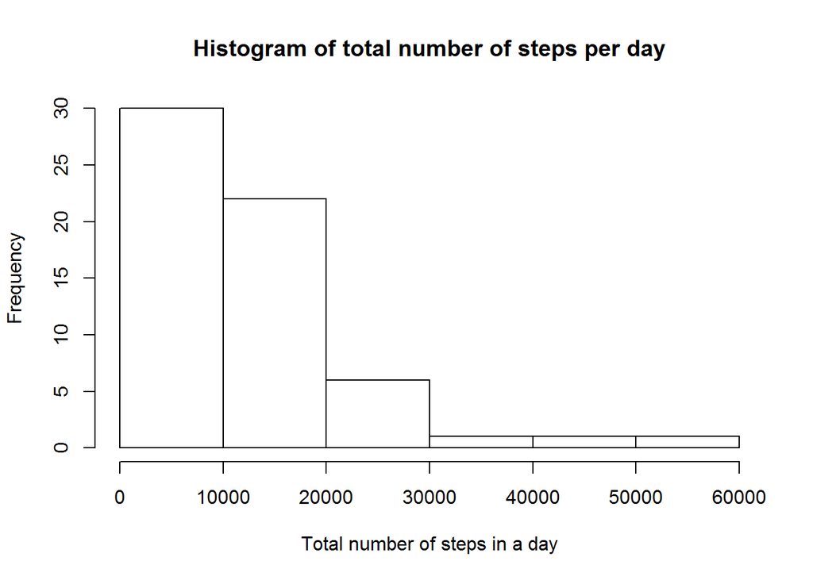

```r
dfsum<- aggregate(df$steps, by=list(date=df$date), FUN=sum)
hist(dfsum$x,main="Histogram of total number of steps per day",  xlab="Total number of steps in a day")
```

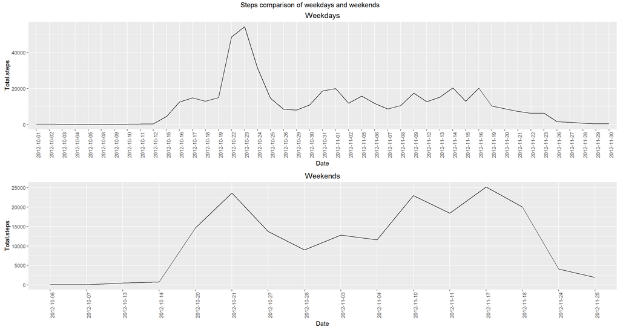

```r
#create a data set with column stating the day of the week for the day
dfweek<-cbind(dfsum,weekdays(as.Date(as.character(dfsum$date))))
colnames(dfweek)<- c("Date","Total.steps","Day")
#create a data frame to save the total steps on each day for weekdays
dfweekday<- dfweek[dfweek$Day %in% c("Monday","Tuesday","Wednesday","Thursday","Friday"),]
#create a data frame to save the total steps on each day for weekdays
dfweekend<- dfweek[dfweek$Day %in% c("Saturday","Sunday"),]

p1<-ggplot(dfweekday,aes(x=Date,y=Total.steps))+geom_line(aes(group=1))+theme(axis.text.x = element_text(angle = 90, hjust = 1))+ggtitle(label = "Weekdays")
p2<- ggplot(dfweekend,aes(x=Date,y=Total.steps))+geom_line(aes(group=1))+theme(axis.text.x = element_text(angle = 90, hjust = 1))+ggtitle(label = "Weekends")
grid.arrange(p1, p2, ncol = 1, top = "Steps comparison of weekdays and weekends")
```

Thus we complete the assignment. Hope you liked it. Please leave a comment to let me know how i did. Thank you.